# Energy Production Forecasting

Classical Forecasting, Machine Learning, Deep Learning, Ensembles and Zero-Shot Foundation Models

Author

Marcin Szalacha

# 1 Project Overview

This project benchmarks a broad range of forecasting approaches for monthly energy production data.

The modelling framework combines:

- classical statistical forecasting
- machine learning
- deep learning
- ensemble methods
- global forecasting
- series-specific forecasting
- zero-shot time-series foundation models

All approaches are evaluated using a common **24-month holdout period**.

The primary evaluation metrics are:

- **RMSE** — Root Mean Squared Error
- **MAE** — Mean Absolute Error
- **MAPE** — Mean Absolute Percentage Error

The project addresses three main questions:

1. Which forecasting approach produces the lowest forecasting error?
2. Does a single global model outperform models fitted separately to individual energy series?
3. Can zero-shot foundation models such as Chronos-2 and TimesFM 3.0 compete with models trained directly on the historical data?

**Headline Result**

The best overall model is **DEEPAR**, with a 24-month holdout RMSE of **0.081**.

# 2 Data

The dataset contains monthly production values for multiple energy sources, including fossil fuels, nuclear energy and renewable energy.

The analysis focuses on ten energy-production series and uses observations from 2010 onward.

Energy series included in the forecasting benchmark.

| Energy Production Series |
| --- |
| Biomass Energy Production |
| Coal Production |
| Crude Oil Production |
| Geothermal Energy Production |
| Hydroelectric Power Production |
| Natural Gas (Dry) Production |
| Natural Gas Plant Liquids Production |
| Nuclear Electric Power Production |
| Solar Energy Production |
| Wind Energy Production |

## 2.1 Data Preparation

The original monthly energy data are filtered from 2010 onward, grouped by energy source and aggregated to monthly frequency.

Missing periods are padded and zero values generated by padding are treated as missing observations before time-series imputation.

# 3 Exploratory Analysis

The individual energy series differ substantially in scale, trend, volatility and seasonal behaviour.

These structural differences motivate the use of a broad forecasting benchmark rather than relying on a single modelling approach.

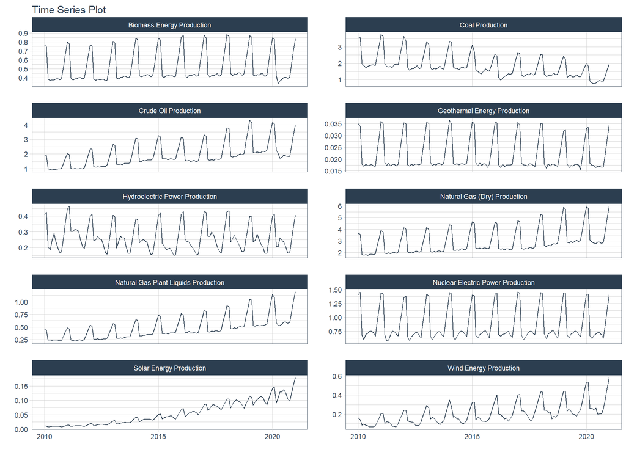

Monthly energy production series from 2010 onward.

The historical series show substantial variation in long-term trends and seasonal patterns.

Some energy sources exhibit relatively stable behaviour, while others show stronger structural changes over time. This supports testing multiple model families rather than assuming a single statistical structure applies equally well to every series.

# 4 Forecasting Design

All models are evaluated using the same **24-month out-of-sample holdout period**.

The project compares two forecasting strategies:

- **Global forecasting** — a single model learns patterns across all energy series.
- **Series-specific forecasting** — separate candidate models are fitted and selected for each individual energy series.

Machine-learning models use lag features, calendar features or hybrid feature sets.

Recursive forecasting is used where future lagged target values need to be generated iteratively.

## 4.1 Train-Test Split

The final 24 months of observations are reserved as an out-of-sample evaluation period.

The same holdout is used for:

- classical models
- machine-learning models
- deep-learning models
- ensemble models
- Chronos-2
- TimesFM 3.0

Using a common test period makes performance directly comparable across modelling families.

Common out-of-sample evaluation period.

| First Holdout Date | Last Holdout Date | Months in Holdout |
| --- | --- | --- |
| 2019-02-01 | 2021-01-01 | 24 |

## 4.2 Global vs Series-Specific Forecasting

A **global model** learns from all energy series simultaneously and can exploit patterns shared between related time series.

A **series-specific approach** fits candidate models independently to each energy source and selects the strongest model separately for each series.

This comparison tests whether shared information across multiple series is more valuable than individual specialization.

# 5 Classical Forecasting Models

The classical forecasting benchmark includes:

- Seasonal Naive
- Rolling Mean baselines
- ETS
- TBATS
- STL + ETS
- ARIMA
- NNETAR

These approaches provide statistical baselines against which more complex models can be assessed.

Classical forecasting model performance.

| Model | RMSE | MAE | MAPE |
| --- | --- | --- | --- |
| SNAIVE [12] | 0.189 | 0.103 | 10.794 |
| WINDOW FUNC [12] | 0.504 | 0.280 | 26.563 |
| WINDOW FUNC [6] | 0.516 | 0.321 | 30.661 |
| ARIMA(4,0,1)(0,0,1)[12] WITH NON-ZERO MEAN W/ XGBOOST ERRORS | 0.670 | 0.423 | 246.342 |
| SEASONAL DECOMP: ETS(A,N,N) | 1.226 | 0.859 | 703.306 |
| ARIMA(2,0,1)(1,0,0)[12] WITH NON-ZERO MEAN | 1.227 | 0.890 | 631.710 |
| TBATS(0.062, {1,4}, 0.964, {<12,2>}) | 1.312 | 0.806 | 377.590 |
| ETS(M,AD,A) | 1.441 | 1.301 | 1321.981 |
| NNAR(1,1,10)[12] | 1.700 | 1.141 | 635.360 |

# 6 Machine Learning Models

The machine-learning benchmark evaluates several supervised learning algorithms for multi-series energy forecasting.

The candidate models include:

- **Elastic Net**
- **XGBoost**
- **LightGBM**
- **Random Forest**
- **Support Vector Regression**

Three feature-engineering strategies are compared where applicable:

- **Lag features** — historical observations from previous periods
- **Calendar features** — date-derived predictors such as month and year
- **Hybrid features** — calendar features combined with lagged values

For models dependent on lagged targets, recursive forecasting is used across the 24-month horizon.

Top machine-learning model configurations.

| Model | RMSE | MAE | MAPE |
| --- | --- | --- | --- |
| RECURSIVE GLMNET | 0.140 | 0.082 | 18.277 |
| RECURSIVE GLMNET | 0.141 | 0.082 | 18.406 |
| RECURSIVE XGBOOST | 0.206 | 0.112 | 14.358 |
| RECURSIVE RANDOMFOREST | 0.217 | 0.118 | 14.538 |
| RECURSIVE RANDOMFOREST | 0.224 | 0.122 | 14.870 |
| RANDOMFOREST | 0.232 | 0.132 | 32.806 |
| LIGHTGBM | 0.243 | 0.158 | 54.986 |
| RECURSIVE LIGHTGBM | 0.246 | 0.120 | 13.605 |
| RECURSIVE KERNLAB | 0.262 | 0.120 | 10.159 |
| RECURSIVE KERNLAB | 0.278 | 0.199 | 108.411 |
| RECURSIVE XGBOOST | 0.290 | 0.159 | 22.806 |
| LIGHTGBM | 0.308 | 0.225 | 106.879 |

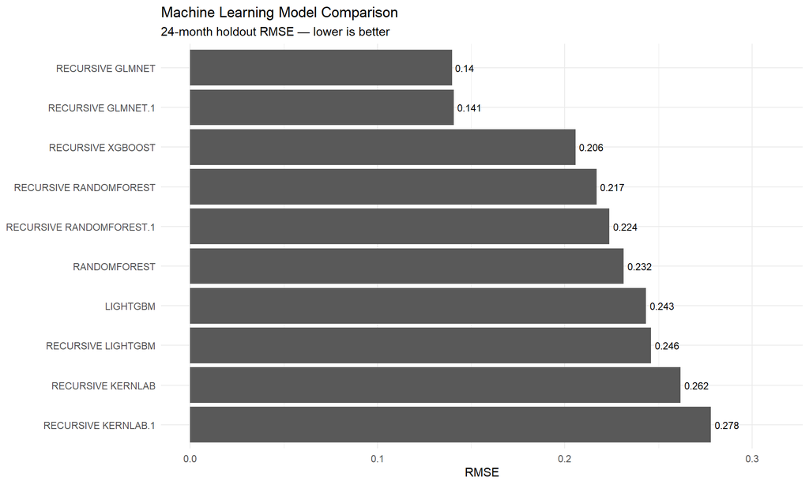

Top machine-learning configurations ranked by holdout RMSE.

```r
ml_plot <- ml_accuracy_tbl |>
  slice_head(n = 10) |>
  mutate(
    model_label = make.unique(.model_desc),
    model_label = factor(
      model_label,
      levels = rev(model_label)
    )
  )

ggplot(
  ml_plot,
  aes(
    x = rmse,
    y = model_label
  )
) +
  geom_col() +
  geom_text(
    aes(
      label = round(rmse, 3)
    ),
    hjust = -0.15,
    size = 3
  ) +
  labs(
    title = "Machine Learning Model Comparison",
    subtitle = "24-month holdout RMSE — lower is better",
    x = "RMSE",
    y = NULL
  ) +
  expand_limits(
    x = max(ml_plot$rmse) * 1.12
  ) +
  theme_minimal()
```

The strongest conventional machine-learning configuration was **RECURSIVE GLMNET**, with an RMSE of **0.14**.

Tree-based models were competitive, but the strongest machine-learning models did not outperform the leading deep-learning and ensemble approaches.

# 7 Deep Learning Models

DeepAR is particularly well suited to collections of related time series because it learns a shared probabilistic forecasting model across multiple series.

Deep-learning model performance.

| Model | RMSE | MAE | MAPE |
| --- | --- | --- | --- |
| DEEPAR | 0.081 | 0.044 | 4.564 |
| DEEPSTATE | 0.106 | 0.050 | 4.843 |

The strongest deep-learning model also ranks at the top of the complete forecasting benchmark.

# 8 Hyperparameter Tuning

LightGBM was selected for a targeted hyperparameter-tuning experiment.

Boosting models can be sensitive to parameters such as:

- learning rate
- tree depth
- number of trees
- minimum observations per node

To control computational cost, tuning was restricted to a smaller rolling time-series cross-validation design.

## 8.1 Best LightGBM Parameters

Selected LightGBM hyperparameters.

| tree_depth | learn_rate | .config |
| --- | --- | --- |
| 3 | 0.3162 | pre0_mod2_post0 |

## 8.2 Tuning Results

LightGBM tuning results.

| tree_depth | learn_rate | .metric | .estimator | mean | n | std_err | .config |
| --- | --- | --- | --- | --- | --- | --- | --- |
| 1 | 0.0100 | mae | standard | 0.4520 | 3 | 0.0232 | pre0_mod1_post0 |
| 1 | 0.0100 | rmse | standard | 0.6655 | 3 | 0.0500 | pre0_mod1_post0 |
| 3 | 0.3162 | mae | standard | 0.0551 | 3 | 0.0093 | pre0_mod2_post0 |
| 3 | 0.3162 | rmse | standard | 0.1069 | 3 | 0.0354 | pre0_mod2_post0 |
| 6 | 0.0010 | mae | standard | 0.6047 | 3 | 0.0279 | pre0_mod3_post0 |
| 6 | 0.0010 | rmse | standard | 0.8153 | 3 | 0.0561 | pre0_mod3_post0 |
| 9 | 0.0316 | mae | standard | 0.0678 | 3 | 0.0122 | pre0_mod4_post0 |
| 9 | 0.0316 | rmse | standard | 0.1231 | 3 | 0.0352 | pre0_mod4_post0 |
| 12 | 0.0032 | mae | standard | 0.3257 | 3 | 0.0280 | pre0_mod5_post0 |
| 12 | 0.0032 | rmse | standard | 0.4695 | 3 | 0.0575 | pre0_mod5_post0 |

The tuned LightGBM configuration did not outperform the strongest deep-learning or ensemble models on the final holdout period.

This provides useful evidence that hyperparameter tuning does not automatically translate into superior out-of-sample forecasting performance.

# 9 Ensemble Models

The project evaluates several ensemble strategies:

- Mean Ensemble
- Median Ensemble
- Weighted Ensemble
- Elastic-Net Stacked Ensemble

The simple ensembles combine predictions from the strongest individual candidates.

The stacked ensemble uses out-of-sample base-model predictions and trains an Elastic Net meta-learner.

Ensemble forecasting performance.

[output not shown]

The simple ensembles performed extremely well and ranked close to the best individual model in the overall benchmark.

This suggests that combining several strong forecasts can provide substantial gains without requiring a more complex standalone model.

# 10 Global Model Benchmark

The following chart compares the strongest global forecasting candidates using the common 24-month holdout period.

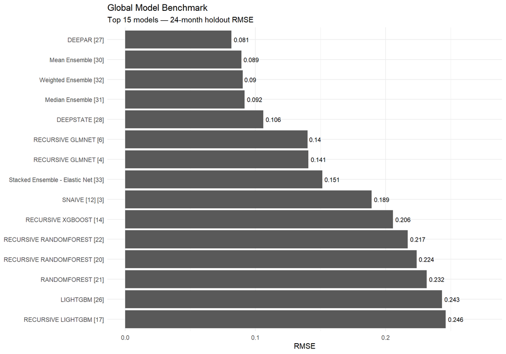

Top 15 global forecasting candidates ranked by holdout RMSE.

The benchmark shows a clear leading group consisting of the strongest deep-learning and ensemble approaches, while several classical and machine-learning methods remain competitive but produce larger forecasting errors.

# 11 Series-Specific Forecasting

A second modelling strategy fits candidate models independently to each energy series.

For computational stability, the local candidate set includes:

- Seasonal Naive
- ETS
- ARIMA
- XGBoost

The strongest local model for each series is selected using holdout RMSE.

Best series-specific model for each energy source.

| Energy Series | Selected Model | RMSE | MAE | MAPE |
| --- | --- | --- | --- | --- |
| Geothermal Energy Production | XGBOOST | 0.001 | 0.001 | 3.289 |
| Solar Energy Production | ARIMA | 0.007 | 0.005 | 6.082 |
| Biomass Energy Production | ETSMAM | 0.009 | 0.006 | 1.142 |
| Nuclear Electric Power Production | ETSANA | 0.019 | 0.015 | 2.000 |
| Hydroelectric Power Production | ETSMNM | 0.020 | 0.018 | 7.217 |
| Wind Energy Production | ETSMAM | 0.022 | 0.017 | 6.719 |
| Natural Gas Plant Liquids Production | ARIMA | 0.050 | 0.039 | 6.189 |
| Coal Production | XGBOOST | 0.109 | 0.077 | 4.466 |
| Crude Oil Production | ARIMA | 0.246 | 0.168 | 6.204 |
| Natural Gas (Dry) Production | ETSMADM | 0.393 | 0.283 | 7.687 |

# 12 Global vs Series-Specific Results

The chart below compares the best global forecasting approach against the best series-specific approach for each energy source.

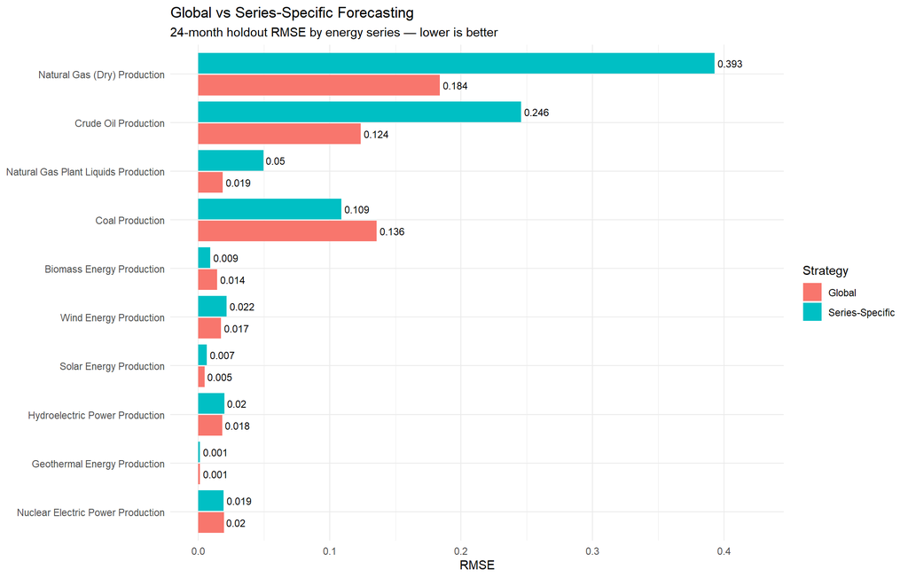

Global and series-specific forecasting performance by energy series.

```r
global_vs_local_plot <- global_vs_local |>
  select(
    id,
    global_rmse,
    local_rmse
  ) |>
  mutate(
    rmse_gap = abs(
      global_rmse - local_rmse
    )
  ) |>
  arrange(rmse_gap) |>
  mutate(
    id = factor(
      id,
      levels = id
    )
  ) |>
  pivot_longer(
    cols = c(
      global_rmse,
      local_rmse
    ),
    names_to = "strategy",
    values_to = "rmse"
  ) |>
  mutate(
    strategy = recode(
      strategy,
      global_rmse = "Global",
      local_rmse = "Series-Specific"
    )
  )

ggplot(
  global_vs_local_plot,
  aes(
    x = rmse,
    y = id,
    fill = strategy
  )
) +
  geom_col(
    position = position_dodge(
      width = 0.9
    ),
    width = 0.85
  ) +
  geom_text(
    aes(
      label = round(
        rmse,
        3
      )
    ),
    position = position_dodge(
      width = 0.9
    ),
    hjust = -0.12,
    size = 3
  ) +
  labs(
    title = "Global vs Series-Specific Forecasting",
    subtitle = "24-month holdout RMSE by energy series — lower is better",
    x = "RMSE",
    y = NULL,
    fill = "Strategy"
  ) +
  expand_limits(
    x = max(
      global_vs_local_plot$rmse
    ) * 1.08
  ) +
  theme_minimal()
```

## 12.1 Winner Summary

Number of energy series won by each forecasting strategy.

| Strategy | Number of Series |
| --- | --- |
| Global | 6 |
| Series-Specific | 4 |

The global strategy wins **6** of the ten energy series, while series-specific models win **4**.

This suggests a practical hybrid forecasting architecture: use a strong global model as the default while allowing specialized local models where they produce a meaningful performance improvement.

# 13 Foundation Models

The project also benchmarks modern pretrained time-series foundation models in a **zero-shot** setting.

Unlike the trained models above, the foundation models are not fitted specifically to the energy dataset before generating forecasts.

Both models are evaluated on exactly the same 24-month holdout period.

## 13.1 Chronos-2

Chronos-2 is evaluated as a zero-shot foundation model.

Chronos-2 zero-shot performance.

| Model | RMSE | MAE | MAPE |
| --- | --- | --- | --- |
| Chronos-2 Zero-Shot | 0.18 | 0.092 | 7.742 |

### 13.1.1 Chronos-2 Performance by Series

Chronos-2 performance by energy series.

| Energy Series | RMSE | MAE | MAPE |
| --- | --- | --- | --- |
| Geothermal Energy Production | 0.001 | 0.001 | 3.515 |
| Solar Energy Production | 0.013 | 0.009 | 6.654 |
| Hydroelectric Power Production | 0.015 | 0.009 | 3.701 |
| Nuclear Electric Power Production | 0.018 | 0.015 | 1.881 |
| Natural Gas Plant Liquids Production | 0.031 | 0.026 | 4.229 |
| Wind Energy Production | 0.036 | 0.027 | 8.219 |
| Biomass Energy Production | 0.040 | 0.033 | 7.438 |
| Natural Gas (Dry) Production | 0.230 | 0.200 | 5.877 |
| Coal Production | 0.238 | 0.205 | 19.147 |
| Crude Oil Production | 0.456 | 0.394 | 16.756 |

Chronos-2 achieved an overall RMSE of **0.18**.

## 13.2 TimesFM 3.0

TimesFM 3.0 is also evaluated zero-shot on the same forecasting horizon.

TimesFM 3.0 zero-shot performance.

| Model | RMSE | MAE | MAPE |
| --- | --- | --- | --- |
| TimesFM 3.0 Zero-Shot | 0.214 | 0.105 | 8.744 |

### 13.2.1 TimesFM 3.0 Performance by Series

TimesFM 3.0 performance by energy series.

| Energy Series | RMSE | MAE | MAPE |
| --- | --- | --- | --- |
| Geothermal Energy Production | 0.001 | 0.001 | 3.456 |
| Hydroelectric Power Production | 0.015 | 0.011 | 4.645 |
| Solar Energy Production | 0.015 | 0.012 | 9.521 |
| Nuclear Electric Power Production | 0.024 | 0.020 | 2.366 |
| Wind Energy Production | 0.034 | 0.027 | 8.581 |
| Natural Gas Plant Liquids Production | 0.041 | 0.034 | 5.296 |
| Biomass Energy Production | 0.043 | 0.035 | 7.655 |
| Coal Production | 0.282 | 0.246 | 22.190 |
| Natural Gas (Dry) Production | 0.311 | 0.257 | 7.189 |
| Crude Oil Production | 0.525 | 0.409 | 16.544 |

TimesFM 3.0 achieved an overall RMSE of **0.214**.

Chronos-2 outperformed TimesFM 3.0 in the zero-shot comparison, but neither foundation model surpassed the strongest models trained specifically on this dataset.

# 14 Final Benchmark

The final benchmark combines:

- classical forecasting
- machine learning
- deep learning
- ensemble methods
- Chronos-2
- TimesFM 3.0

## 14.1 Top Models

Top 15 forecasting approaches in the complete benchmark.

| Model | RMSE | MAE | MAPE |
| --- | --- | --- | --- |
| DEEPAR | 0.081 | 0.044 | 4.564 |
| Mean Ensemble | 0.089 | 0.045 | 7.150 |
| Weighted Ensemble | 0.090 | 0.048 | 8.906 |
| Median Ensemble | 0.092 | 0.049 | 7.214 |
| DEEPSTATE | 0.106 | 0.050 | 4.843 |
| RECURSIVE GLMNET | 0.140 | 0.082 | 18.277 |
| RECURSIVE GLMNET | 0.141 | 0.082 | 18.406 |
| Stacked Ensemble - Elastic Net | 0.151 | 0.088 | 14.031 |
| Chronos-2 Zero-Shot | 0.180 | 0.092 | 7.742 |
| SNAIVE [12] | 0.189 | 0.103 | 10.794 |
| RECURSIVE XGBOOST | 0.206 | 0.112 | 14.358 |
| TimesFM 3.0 Zero-Shot | 0.214 | 0.105 | 8.744 |
| RECURSIVE RANDOMFOREST | 0.217 | 0.118 | 14.538 |
| RECURSIVE RANDOMFOREST | 0.224 | 0.122 | 14.870 |
| RANDOMFOREST | 0.232 | 0.132 | 32.806 |

## 14.2 Final Benchmark Chart

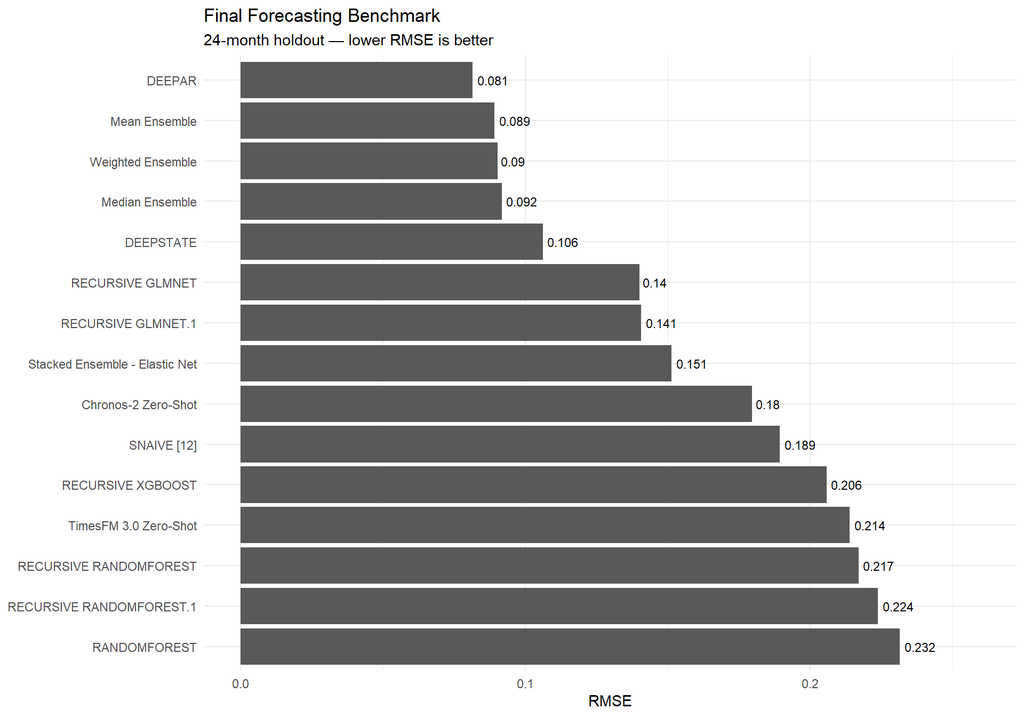

Final benchmark across classical, machine-learning, deep-learning, ensemble and foundation models.

```r
final_benchmark_plot <- final_benchmark_tbl |>
  mutate(
    model_label = make.unique(
      .model_desc
    )
  ) |>
  arrange(rmse) |>
  slice_head(
    n = 15
  ) |>
  mutate(
    model_label = factor(
      model_label,
      levels = rev(
        model_label
      )
    )
  )

ggplot(
  final_benchmark_plot,
  aes(
    x = rmse,
    y = model_label
  )
) +
  geom_col() +
  geom_text(
    aes(
      label = round(
        rmse,
        3
      )
    ),
    hjust = -0.15,
    size = 3
  ) +
  labs(
    title = "Final Forecasting Benchmark",
    subtitle = "24-month holdout — lower RMSE is better",
    x = "RMSE",
    y = NULL
  ) +
  expand_limits(
    x = max(
      final_benchmark_plot$rmse
    ) * 1.12
  ) +
  theme_minimal()
```

**Best Overall Model**

**DEEPAR** achieved the lowest overall RMSE at **0.081**.

The strongest alternatives were the ensemble methods, which achieved performance very close to the winning model.

Chronos-2 achieved an RMSE of **0.18**, while TimesFM 3.0 achieved **0.214**.

The zero-shot foundation models therefore produced useful forecasts without dataset-specific training, but they did not outperform the strongest trained deep-learning and ensemble approaches.

# 15 Key Findings

1. **DEEPAR achieved the best overall forecasting performance**, with an RMSE of **0.081**.
2. **Simple ensembles were extremely competitive**, ranking very close to the strongest individual model.
3. **Global forecasting won 6 of the ten energy series**, while series-specific models won 4.
4. **RECURSIVE GLMNET was the strongest conventional machine-learning configuration**, with an RMSE of **0.14**.
5. **Chronos-2 outperformed TimesFM 3.0 in the zero-shot benchmark**, with RMSE values of **0.18** and **0.214**, respectively.
6. **Hyperparameter tuning did not guarantee better holdout performance.** The tuned LightGBM configuration remained below several alternative forecasting approaches.
7. The results demonstrate that newer or more complex models do not automatically provide better forecasting performance.
8. A promising practical architecture is a **hybrid forecasting system** combining a strong global model with local specialization for selected series.

# 16 Limitations

Several limitations should be considered when interpreting the benchmark.

- The final benchmark uses one 24-month holdout period.
- Hyperparameter tuning was intentionally constrained to control computational cost.
- Deep-learning and foundation models were evaluated on CPU.
- External drivers such as energy prices, weather, policy changes and macroeconomic variables were not included.
- The local model candidate set was smaller than the global candidate set.
- Foundation models were evaluated zero-shot rather than fine-tuned.
- Additional rolling-origin evaluation could further test model robustness.
- Deep-learning performance could be explored further using alternative architecture settings and longer training schedules.

# 17 Reproducibility

The complete modelling workflow is retained in the accompanying R script.

The Quarto report reads saved model outputs rather than retraining every model during rendering.

This separates **model development** from **report generation**, keeping the portfolio page fast and reproducible while preserving the complete modelling workflow separately.

The project structure is:

```
Energy_Production_Forecasting/
│
├── Energy_Production_Forecasting_FINAL.R
├── Energy_Production_Forecasting.qmd
│
├── data/
│   ├── energy_production.xlsx
│   └── foundation/
│       ├── context.csv
│       └── truth.csv
│
├── outputs/
│   ├── global_accuracy.csv
│   ├── global_accuracy_by_series.csv
│   ├── all_models_accuracy.csv
│   ├── ensemble_accuracy.csv
│   ├── local_model_accuracy.csv
│   ├── global_vs_local.csv
│   ├── final_model_benchmark.csv
│   ├── chronos2_accuracy.csv
│   ├── chronos2_accuracy_by_series.csv
│   ├── timesfm3_accuracy.csv
│   ├── timesfm3_accuracy_by_series.csv
│   ├── lightgbm_tuning_results.csv
│   └── best_lightgbm_parameters.csv
│
└── models/
    ├── best_global_model.rds
    ├── best_local_models.rds
    └── tuned_lightgbm.rds
```